# Practical_ML_Accelerometer

Simo

April 24, 2019

## 1. Specfic aim and background

#### This project aims to use accelemetors derived from Unilateral Dumbbell Biceps Curl on differnt body parts including belft, foreeam, arm and dumbell from the six participants to predict the five classes of barbell lifts acitivity. Five classes include exactly according to the specification (Class A), throwing the elbows to the front (Class B), lifting the dumbbell only halfway (Class C), lowering the dumbbell only halfway (Class D) and throwing the hips to the front (Class E)

## 2. Load dataset

```r
## read dataset
train<- read.csv("C:/Users/sdu7/Box Sync/miscellaneous/ML/pml-training.csv")

test<- read.csv("C:/Users/sdu7/Box Sync/miscellaneous/ML/pml-testing.csv")


## dataset exploration
dim(train)
```

```
## [1] 19622   160
```

```r
dim(test)
```

```
## [1]  20 160
```

```r
## method: rf, gam, gbm, lasso,
## accuracy checking
## prediction
## background search
```

## 3. Explore the dataset, missing values, outcome pattern freqency etc.

```r
summary(train)
```

```
##        X            user_name    raw_timestamp_part_1 raw_timestamp_part_2
##  Min.   :    1   adelmo  :3892   Min.   :1.322e+09    Min.   :   294
##  1st Qu.: 4906   carlitos:3112   1st Qu.:1.323e+09    1st Qu.:252912
##  Median : 9812   charles :3536   Median :1.323e+09    Median :496380
##  Mean   : 9812   eurico  :3070   Mean   :1.323e+09    Mean   :500656
##  3rd Qu.:14717   jeremy  :3402   3rd Qu.:1.323e+09    3rd Qu.:751891
##  Max.   :19622   pedro   :2610   Max.   :1.323e+09    Max.   :998801
##
##           cvtd_timestamp  new_window    num_window      roll_belt
##  28/11/2011 14:14: 1498   no :19216   Min.   :  1.0   Min.   :-28.90
##  5/12/2011 11:24 : 1497   yes:  406   1st Qu.:222.0   1st Qu.:  1.10
##  30/11/2011 17:11: 1440               Median :424.0   Median :113.00
##  5/12/2011 11:25 : 1425               Mean   :430.6   Mean   : 64.41
##  2/12/2011 14:57 : 1380               3rd Qu.:644.0   3rd Qu.:123.00
##  2/12/2011 13:34 : 1375               Max.   :864.0   Max.   :162.00
##  (Other)         :11007
##    pitch_belt          yaw_belt       total_accel_belt kurtosis_roll_belt
##  Min.   :-55.8000   Min.   :-180.00   Min.   : 0.00             :19216
##  1st Qu.:  1.7600   1st Qu.: -88.30   1st Qu.: 3.00    #DIV/0!  :   10
##  Median :  5.2800   Median : -13.00   Median :17.00    -1.908453:    2
##  Mean   :  0.3053   Mean   : -11.21   Mean   :11.31    -0.01685 :    1
##  3rd Qu.: 14.9000   3rd Qu.:  12.90   3rd Qu.:18.00    -0.021024:    1
##  Max.   : 60.3000   Max.   : 179.00   Max.   :29.00    -0.025513:    1
##                                                        (Other)  :  391
##  kurtosis_picth_belt kurtosis_yaw_belt skewness_roll_belt
##           :19216            :19216              :19216
##  #DIV/0!  :   32     #DIV/0!:  406     #DIV/0!  :    9
##  47       :    4                       0        :    4
##  -0.15095 :    3                       0.422463 :    2
##  -0.684748:    3                       -0.003095:    1
##  -1.750749:    3                       -0.010002:    1
##  (Other)  :  361                       (Other)  :  389
##  skewness_roll_belt.1 skewness_yaw_belt max_roll_belt     max_picth_belt
##           :19216             :19216     Min.   :-94.300   Min.   : 3.00
##  #DIV/0!  :   32      #DIV/0!:  406     1st Qu.:-88.000   1st Qu.: 5.00
##  0        :    4                        Median : -5.100   Median :18.00
##  -2.156553:    3                        Mean   : -6.667   Mean   :12.92
##  -3.072669:    3                        3rd Qu.: 18.500   3rd Qu.:19.00
##  -6.324555:    3                        Max.   :180.000   Max.   :30.00
##  (Other)  :  361                        NA's   :19216     NA's   :19216
```

[output cut: 313 more lines]

```
##  Min.   :-446.00   Min.   :-1280.0   Min.   :-896.0   Min.   :-973.0
##  1st Qu.:-182.00   1st Qu.: -616.0   1st Qu.:   2.0   1st Qu.: 191.0
##  Median : -39.00   Median : -378.0   Median : 591.0   Median : 511.0
##  Mean   : -55.29   Mean   : -312.6   Mean   : 380.1   Mean   : 393.6
##  3rd Qu.:  26.00   3rd Qu.:  -73.0   3rd Qu.: 737.0   3rd Qu.: 653.0
##  Max.   : 291.00   Max.   :  672.0   Max.   :1480.0   Max.   :1090.0
##
##  classe
##  A:5580
##  B:3797
##  C:3422
##  D:3216
##  E:3607
##
##
```

```r
#### the number of missing cases for each variable
colSums(is.na(train))
```

```
##                        X                user_name     raw_timestamp_part_1
##                        0                        0                        0
##     raw_timestamp_part_2           cvtd_timestamp               new_window
##                        0                        0                        0
##               num_window                roll_belt               pitch_belt
##                        0                        0                        0
##                 yaw_belt         total_accel_belt       kurtosis_roll_belt
##                        0                        0                        0
##      kurtosis_picth_belt        kurtosis_yaw_belt       skewness_roll_belt
##                        0                        0                        0
##     skewness_roll_belt.1        skewness_yaw_belt            max_roll_belt
##                        0                        0                    19216
##           max_picth_belt             max_yaw_belt            min_roll_belt
##                    19216                        0                    19216
##           min_pitch_belt             min_yaw_belt      amplitude_roll_belt
##                    19216                        0                    19216
##     amplitude_pitch_belt       amplitude_yaw_belt     var_total_accel_belt
##                    19216                        0                    19216
##            avg_roll_belt         stddev_roll_belt            var_roll_belt
##                    19216                    19216                    19216
##           avg_pitch_belt        stddev_pitch_belt           var_pitch_belt
##                    19216                    19216                    19216
##             avg_yaw_belt          stddev_yaw_belt             var_yaw_belt
##                    19216                    19216                    19216
##             gyros_belt_x             gyros_belt_y             gyros_belt_z
##                        0                        0                        0
##             accel_belt_x             accel_belt_y             accel_belt_z
##                        0                        0                        0
##            magnet_belt_x            magnet_belt_y            magnet_belt_z
##                        0                        0                        0
##                 roll_arm                pitch_arm                  yaw_arm
##                        0                        0                        0
##          total_accel_arm            var_accel_arm             avg_roll_arm
##                        0                    19216                    19216
##          stddev_roll_arm             var_roll_arm            avg_pitch_arm
##                    19216                    19216                    19216
##         stddev_pitch_arm            var_pitch_arm              avg_yaw_arm
##                    19216                    19216                    19216
##           stddev_yaw_arm              var_yaw_arm              gyros_arm_x
##                    19216                    19216                        0
```

[output cut: 53 more lines]

```
##                        0                        0                    19216
##         avg_roll_forearm      stddev_roll_forearm         var_roll_forearm
##                    19216                    19216                    19216
##        avg_pitch_forearm     stddev_pitch_forearm        var_pitch_forearm
##                    19216                    19216                    19216
##          avg_yaw_forearm       stddev_yaw_forearm          var_yaw_forearm
##                    19216                    19216                    19216
##          gyros_forearm_x          gyros_forearm_y          gyros_forearm_z
##                        0                        0                        0
##          accel_forearm_x          accel_forearm_y          accel_forearm_z
##                        0                        0                        0
##         magnet_forearm_x         magnet_forearm_y         magnet_forearm_z
##                        0                        0                        0
##                   classe
##                        0
```

```r
## check the frequency and percent of outcome variables

table(train$classe  )
```

```
##
##    A    B    C    D    E
## 5580 3797 3422 3216 3607
```

```r
prop.table(table(train$classe  ) ) %>%
  round(2)
```

```
##
##    A    B    C    D    E
## 0.28 0.19 0.17 0.16 0.18
```

```r
## cross table the outcome variables with individual
table(train$user_name,train$classe)
```

```
##
##               A    B    C    D    E
##   adelmo   1165  776  750  515  686
##   carlitos  834  690  493  486  609
##   charles   899  745  539  642  711
##   eurico    865  592  489  582  542
##   jeremy   1177  489  652  522  562
##   pedro     640  505  499  469  497
```

```r
prop.table( table( train$user_name,train$classe)  , margin = 1 )  %>%
  round(2)
```

```
##
##               A    B    C    D    E
##   adelmo   0.30 0.20 0.19 0.13 0.18
##   carlitos 0.27 0.22 0.16 0.16 0.20
##   charles  0.25 0.21 0.15 0.18 0.20
##   eurico   0.28 0.19 0.16 0.19 0.18
##   jeremy   0.35 0.14 0.19 0.15 0.17
##   pedro    0.25 0.19 0.19 0.18 0.19
```

## 4.Feature selection:

#### We removed zero variance features, variables missing more than 95% and features that are not useful

```r
## remove zero variance features

featurezero <- nearZeroVar(train,saveMetrics = T )
featurezero
```

```
##                            freqRatio percentUnique zeroVar   nzv
## X                           1.000000  100.00000000   FALSE FALSE
## user_name                   1.100679    0.03057792   FALSE FALSE
## raw_timestamp_part_1        1.000000    4.26562022   FALSE FALSE
## raw_timestamp_part_2        1.000000   85.53154622   FALSE FALSE
## cvtd_timestamp              1.000668    0.10192641   FALSE FALSE
## new_window                 47.330049    0.01019264   FALSE  TRUE
## num_window                  1.000000    4.37264295   FALSE FALSE
## roll_belt                   1.101904    6.77810621   FALSE FALSE
## pitch_belt                  1.036082    9.37722964   FALSE FALSE
## yaw_belt                    1.058480    9.97349913   FALSE FALSE
## total_accel_belt            1.063160    0.14779329   FALSE FALSE
## kurtosis_roll_belt       1921.600000    2.02323922   FALSE  TRUE
## kurtosis_picth_belt       600.500000    1.61553358   FALSE  TRUE
## kurtosis_yaw_belt          47.330049    0.01019264   FALSE  TRUE
## skewness_roll_belt       2135.111111    2.01304658   FALSE  TRUE
## skewness_roll_belt.1      600.500000    1.72255631   FALSE  TRUE
## skewness_yaw_belt          47.330049    0.01019264   FALSE  TRUE
## max_roll_belt               1.000000    0.99378249   FALSE FALSE
## max_picth_belt              1.538462    0.11211905   FALSE FALSE
## max_yaw_belt              640.533333    0.34654979   FALSE  TRUE
## min_roll_belt               1.000000    0.93772296   FALSE FALSE
## min_pitch_belt              2.192308    0.08154113   FALSE FALSE
## min_yaw_belt              640.533333    0.34654979   FALSE  TRUE
## amplitude_roll_belt         1.290323    0.75425543   FALSE FALSE
## amplitude_pitch_belt        3.042254    0.06625217   FALSE FALSE
## amplitude_yaw_belt         48.525253    0.01528896   FALSE  TRUE
## var_total_accel_belt        1.426829    0.33126083   FALSE FALSE
## avg_roll_belt               1.066667    0.97339721   FALSE FALSE
## stddev_roll_belt            1.039216    0.35164611   FALSE FALSE
## var_roll_belt               1.615385    0.48924676   FALSE FALSE
## avg_pitch_belt              1.375000    1.09061258   FALSE FALSE
## stddev_pitch_belt           1.161290    0.21914178   FALSE FALSE
## var_pitch_belt              1.307692    0.32106819   FALSE FALSE
## avg_yaw_belt                1.200000    1.22311691   FALSE FALSE
## stddev_yaw_belt             1.693878    0.29558659   FALSE FALSE
## var_yaw_belt                1.500000    0.73896647   FALSE FALSE
## gyros_belt_x                1.058651    0.71348486   FALSE FALSE
## gyros_belt_y                1.144000    0.35164611   FALSE FALSE
## gyros_belt_z                1.066214    0.86127816   FALSE FALSE
```

[output cut: 106 more lines]

```
## stddev_pitch_forearm       41.500000    1.64611151   FALSE  TRUE
## var_pitch_forearm          83.000000    1.65120783   FALSE  TRUE
## avg_yaw_forearm            83.000000    1.65120783   FALSE  TRUE
## stddev_yaw_forearm         85.000000    1.64101519   FALSE  TRUE
## var_yaw_forearm            85.000000    1.64101519   FALSE  TRUE
## gyros_forearm_x             1.059273    1.51870350   FALSE FALSE
## gyros_forearm_y             1.036554    3.77637346   FALSE FALSE
## gyros_forearm_z             1.122917    1.56457038   FALSE FALSE
## accel_forearm_x             1.126437    4.04647844   FALSE FALSE
## accel_forearm_y             1.059406    5.11160942   FALSE FALSE
## accel_forearm_z             1.006250    2.95586586   FALSE FALSE
## magnet_forearm_x            1.012346    7.76679238   FALSE FALSE
## magnet_forearm_y            1.246914    9.54031189   FALSE FALSE
## magnet_forearm_z            1.000000    8.57710733   FALSE FALSE
## classe                      1.469581    0.02548160   FALSE FALSE
```

```r
## delete those variables whose variance is near zero & check the deleted features
feature_delete <- train[,which(featurezero$nzv == "TRUE")]


##  select non-zero variance features
feature_select <- train[,which(featurezero$nzv == "FALSE")]
 dim(feature_select ) ## 100 features
```

```
## [1] 19622   100
```

```r
 ## only choose those with less than 90% missing
 feature_select2<- feature_select[  , which(colMeans(is.na(feature_select)) < 0.95  )    ]
 dim(feature_select2)  ## 59 features
```

```
## [1] 19622    59
```

```r
 ##  Exclude the first 6 columns which are not useful
 feature_select3<- feature_select2[ ,   -(1:6)]
 dim(feature_select3)
```

```
## [1] 19622    53
```

```r
 str(feature_select3)
```

```
## 'data.frame':    19622 obs. of  53 variables:
##  $ roll_belt           : num  1.41 1.41 1.42 1.48 1.48 1.45 1.42 1.42 1.43 1.45 ...
##  $ pitch_belt          : num  8.07 8.07 8.07 8.05 8.07 8.06 8.09 8.13 8.16 8.17 ...
##  $ yaw_belt            : num  -94.4 -94.4 -94.4 -94.4 -94.4 -94.4 -94.4 -94.4 -94.4 -94.4 ...
##  $ total_accel_belt    : int  3 3 3 3 3 3 3 3 3 3 ...
##  $ gyros_belt_x        : num  0 0.02 0 0.02 0.02 0.02 0.02 0.02 0.02 0.03 ...
##  $ gyros_belt_y        : num  0 0 0 0 0.02 0 0 0 0 0 ...
##  $ gyros_belt_z        : num  -0.02 -0.02 -0.02 -0.03 -0.02 -0.02 -0.02 -0.02 -0.02 0 ...
##  $ accel_belt_x        : int  -21 -22 -20 -22 -21 -21 -22 -22 -20 -21 ...
##  $ accel_belt_y        : int  4 4 5 3 2 4 3 4 2 4 ...
##  $ accel_belt_z        : int  22 22 23 21 24 21 21 21 24 22 ...
##  $ magnet_belt_x       : int  -3 -7 -2 -6 -6 0 -4 -2 1 -3 ...
##  $ magnet_belt_y       : int  599 608 600 604 600 603 599 603 602 609 ...
##  $ magnet_belt_z       : int  -313 -311 -305 -310 -302 -312 -311 -313 -312 -308 ...
##  $ roll_arm            : num  -128 -128 -128 -128 -128 -128 -128 -128 -128 -128 ...
```

[output cut: 39 more lines]

Note: 52 feature have been selected

## 5 Feature exploration , outlier, distribution etc

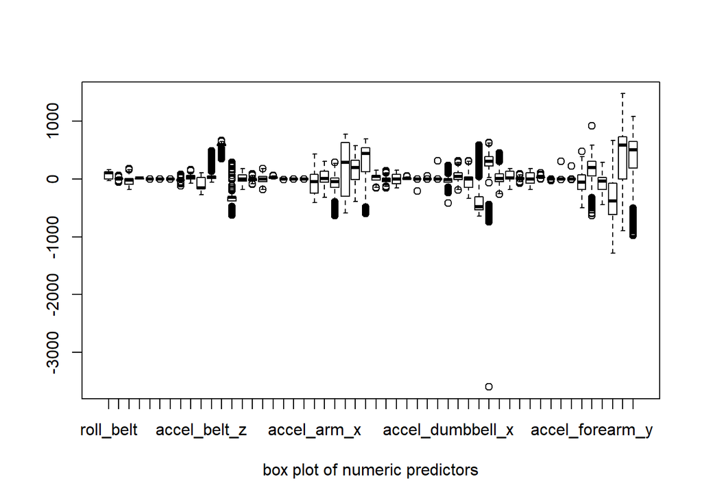

```r
## select only numeric variables

train_num<- select_if(feature_select3, is.numeric )

## check the outlier
##outlier(train_num)

## box plot of numeric features
boxplot(train_num, xlab = "box plot of numeric predictors" )
```

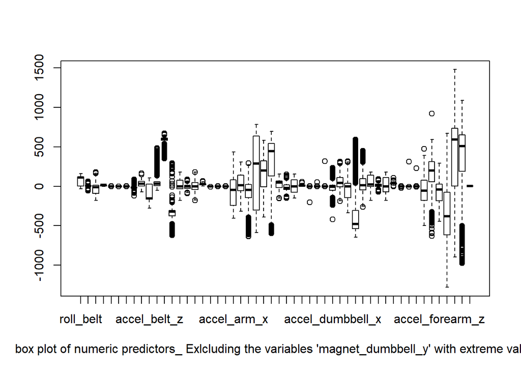

```r
## exlucde the variables "magnet_dumbbell_y"

boxplot( feature_select3[ , -  which(names(feature_select3) == "magnet_dumbbell_y")   ]
         ,  xlab = "box plot of numeric predictors_ Exlcluding the variables 'magnet_dumbbell_y' with extreme value"   )
```

```r
extreme_out <- feature_select3%>% filter(magnet_dumbbell_y < -3000 )

extreme_out
```

```
##   roll_belt pitch_belt yaw_belt total_accel_belt gyros_belt_x gyros_belt_y
## 1      1.56       5.59    -92.8                3         0.06            0
##   gyros_belt_z accel_belt_x accel_belt_y accel_belt_z magnet_belt_x
## 1        -0.02          -19            5           27            -4
##   magnet_belt_y magnet_belt_z roll_arm pitch_arm yaw_arm total_accel_arm
## 1           610          -301      152     -31.7   -77.7              41
##   gyros_arm_x gyros_arm_y gyros_arm_z accel_arm_x accel_arm_y accel_arm_z
## 1        1.61       -0.88        1.02          43         -53        -398
##   magnet_arm_x magnet_arm_y magnet_arm_z roll_dumbbell pitch_dumbbell
## 1          335         -310         -458        104.39       50.77463
##   yaw_dumbbell total_accel_dumbbell gyros_dumbbell_x gyros_dumbbell_y
## 1     12.86598                   15              0.1             0.61
##   gyros_dumbbell_z accel_dumbbell_x accel_dumbbell_y accel_dumbbell_z
## 1            -0.25               72              128               19
##   magnet_dumbbell_x magnet_dumbbell_y magnet_dumbbell_z roll_forearm
## 1              -238             -3600               -41          141
##   pitch_forearm yaw_forearm total_accel_forearm gyros_forearm_x
## 1          43.1         153                  35           -0.45
##   gyros_forearm_y gyros_forearm_z accel_forearm_x accel_forearm_y
## 1            2.95            0.52            -191             241
##   accel_forearm_z magnet_forearm_x magnet_forearm_y magnet_forearm_z
## 1            -162             -697              358              623
##   classe
## 1      B
```

```r
## explore mean and median of magnet_dumbbell_y by five patterns
library(table1)
table1( ~ magnet_dumbbell_y | factor(classe) , data  = feature_select3 %>%  filter(magnet_dumbbell_y > -3000 ) )
```

|  | A (n=5580) | B (n=3796) | C (n=3422) | D (n=3216) | E (n=3607) | Overall (n=19621) |
| --- | --- | --- | --- | --- | --- | --- |
| magnet_dumbbell_y |  |  |  |  |  |  |
| Mean (SD) | 219 (276) | 267 (363) | 158 (305) | 218 (329) | 239 (361) | 221 (326) |
| Median [Min, Max] | 308 [-586, 487] | 364 [-730, 633] | 245 [-744, 582] | 326 [-645, 561] | 327 [-742, 618] | 311 [-744, 633] |

Note: After checking the distribution of the features, we found out that there is a variable named magnet_dumbbell_y with extreme values. We identified the observation with the extreme value and this observation has a class of B, which is the wrong exercise pattern. We also found out that pattern B have higher magnet_dumbbell_y value in general, so we decided to include the observation into our prediction model since this observation is plausible.

## 6. Data split for cross validation

```r
inTrain = createDataPartition(feature_select3$classe, p = 3/4)[[1]]

training = feature_select3[ inTrain,]
validation = feature_select3[- inTrain,]
dim(training)
```

```
## [1] 14718    53
```

```r
dim(validation )
```

```
## [1] 4904   53
```

Note: For cross validation, we split our dataset 75% in trainning vs 25% in validation dataset.

## 7. Training the Model

##### Since random forest and GBM are the two predictive methods that are most accurate and commonly used methods, we are going to use both of them to predict the model and choose the one based on the performance.

```r
## Random forrest methods

set.seed(12345)
fit.rf = randomForest(classe ~ ., data = training )
summary(fit.rf)
```

```
##                 Length Class  Mode
## call                3  -none- call
## type                1  -none- character
## predicted       14718  factor numeric
## err.rate         3000  -none- numeric
## confusion          30  -none- numeric
## votes           73590  matrix numeric
## oob.times       14718  -none- numeric
## classes             5  -none- character
## importance         52  -none- numeric
## importanceSD        0  -none- NULL
## localImportance     0  -none- NULL
## proximity           0  -none- NULL
## ntree               1  -none- numeric
## mtry                1  -none- numeric
## forest             14  -none- list
## y               14718  factor numeric
## test                0  -none- NULL
## inbag               0  -none- NULL
## terms               3  terms  call
```

```r
## generalized boosting method

set.seed(54321)

fit.gbm<-  train(classe ~ . ,  data= training , method = "gbm", na.action = na.omit )
```

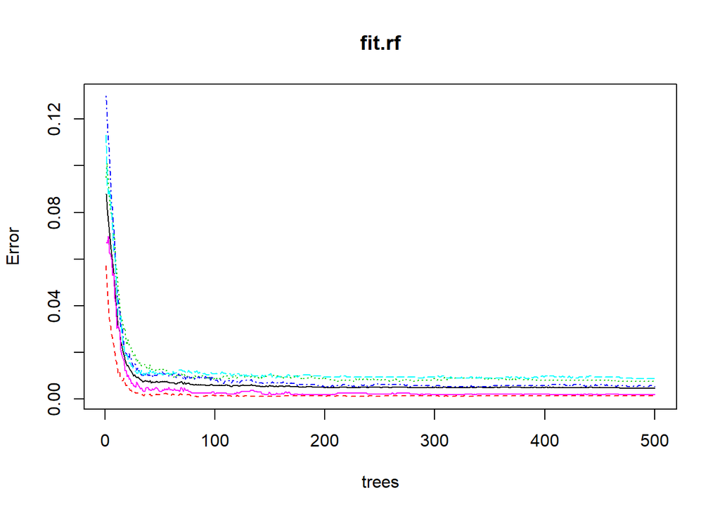

```r
## model plot _random forest

plot(fit.rf)
```

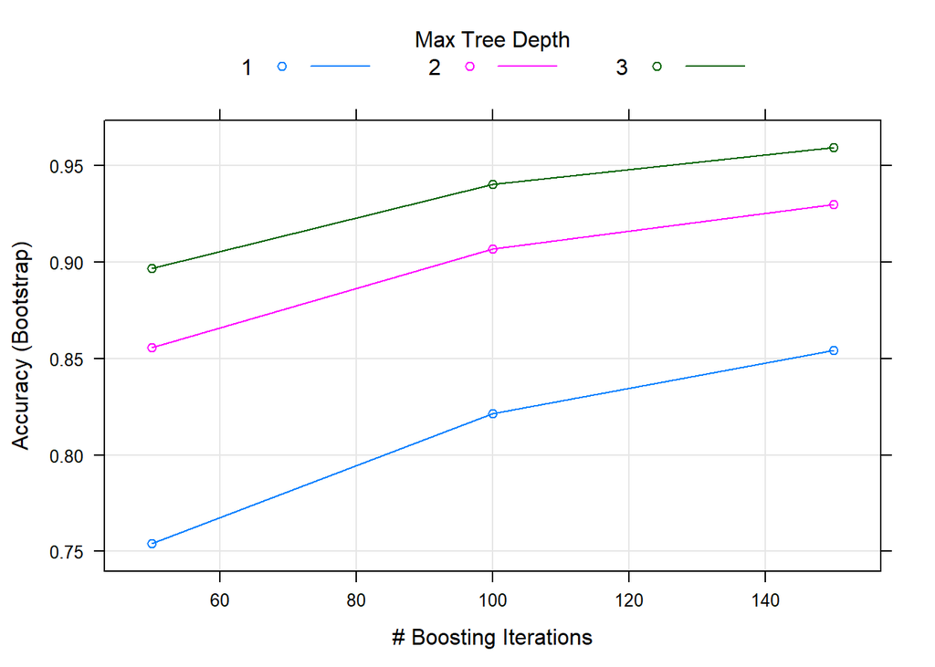

```r
## model plot_ GBM
plot(fit.gbm)
```

```r
##
```

## 8. Model Validation

##### Testing the model performance in training dataset and valudation data set

```r
set.seed(123456)
rf.pred = predict(fit.rf, training)
print(confusionMatrix(rf.pred, training$classe))
```

```
## Confusion Matrix and Statistics
##
##           Reference
## Prediction    A    B    C    D    E
##          A 4185    0    0    0    0
##          B    0 2848    0    0    0
##          C    0    0 2567    0    0
##          D    0    0    0 2412    0
##          E    0    0    0    0 2706
##
## Overall Statistics
##
##                Accuracy : 1
##                  95% CI : (0.9997, 1)
##     No Information Rate : 0.2843
##     P-Value [Acc > NIR] : < 2.2e-16
##
##                   Kappa : 1
##  Mcnemar's Test P-Value : NA
##
## Statistics by Class:
##
##                      Class: A Class: B Class: C Class: D Class: E
## Sensitivity            1.0000   1.0000   1.0000   1.0000   1.0000
## Specificity            1.0000   1.0000   1.0000   1.0000   1.0000
## Pos Pred Value         1.0000   1.0000   1.0000   1.0000   1.0000
## Neg Pred Value         1.0000   1.0000   1.0000   1.0000   1.0000
## Prevalence             0.2843   0.1935   0.1744   0.1639   0.1839
## Detection Rate         0.2843   0.1935   0.1744   0.1639   0.1839
## Detection Prevalence   0.2843   0.1935   0.1744   0.1639   0.1839
## Balanced Accuracy      1.0000   1.0000   1.0000   1.0000   1.0000
```

```r
#### Validate set accuracy

rfvalidation = predict(fit.rf, validation)
print(confusionMatrix(rfvalidation, validation$classe))
```

```
## Confusion Matrix and Statistics
##
##           Reference
## Prediction    A    B    C    D    E
##          A 1395    3    0    0    0
##          B    0  944   10    0    0
##          C    0    2  845    7    0
##          D    0    0    0  797    0
##          E    0    0    0    0  901
##
## Overall Statistics
##
##                Accuracy : 0.9955
##                  95% CI : (0.9932, 0.9972)
##     No Information Rate : 0.2845
##     P-Value [Acc > NIR] : < 2.2e-16
##
##                   Kappa : 0.9943
##  Mcnemar's Test P-Value : NA
##
## Statistics by Class:
##
##                      Class: A Class: B Class: C Class: D Class: E
## Sensitivity            1.0000   0.9947   0.9883   0.9913   1.0000
## Specificity            0.9991   0.9975   0.9978   1.0000   1.0000
## Pos Pred Value         0.9979   0.9895   0.9895   1.0000   1.0000
## Neg Pred Value         1.0000   0.9987   0.9975   0.9983   1.0000
## Prevalence             0.2845   0.1935   0.1743   0.1639   0.1837
## Detection Rate         0.2845   0.1925   0.1723   0.1625   0.1837
## Detection Prevalence   0.2851   0.1945   0.1741   0.1625   0.1837
## Balanced Accuracy      0.9996   0.9961   0.9930   0.9956   1.0000
```

```r
##fit.gbm
####
set.seed(654321)
gbm.pred = predict(fit.gbm, training)
print(confusionMatrix(gbm.pred, training$classe))
```

```
## Confusion Matrix and Statistics
##
##           Reference
## Prediction    A    B    C    D    E
##          A 4140   54    0    1    2
##          B   35 2734   57    6   14
##          C    5   58 2477   63   15
##          D    3    1   31 2329   27
##          E    2    1    2   13 2648
##
## Overall Statistics
##
##                Accuracy : 0.9735
##                  95% CI : (0.9708, 0.976)
##     No Information Rate : 0.2843
##     P-Value [Acc > NIR] : < 2.2e-16
##
##                   Kappa : 0.9665
##  Mcnemar's Test P-Value : 2.037e-07
##
## Statistics by Class:
##
##                      Class: A Class: B Class: C Class: D Class: E
## Sensitivity            0.9892   0.9600   0.9649   0.9656   0.9786
## Specificity            0.9946   0.9906   0.9884   0.9950   0.9985
## Pos Pred Value         0.9864   0.9606   0.9461   0.9741   0.9932
## Neg Pred Value         0.9957   0.9904   0.9926   0.9933   0.9952
## Prevalence             0.2843   0.1935   0.1744   0.1639   0.1839
## Detection Rate         0.2813   0.1858   0.1683   0.1582   0.1799
## Detection Prevalence   0.2852   0.1934   0.1779   0.1625   0.1811
## Balanced Accuracy      0.9919   0.9753   0.9767   0.9803   0.9885
```

```r
#### Validate set accuracy

gbm.valid = predict(fit.gbm, validation)
print(confusionMatrix(gbm.valid, validation$classe))
```

```
## Confusion Matrix and Statistics
##
##           Reference
## Prediction    A    B    C    D    E
##          A 1364   20    0    1    2
##          B   21  893   30    6    8
##          C    5   32  817   20   14
##          D    5    3    4  767   10
##          E    0    1    4   10  867
##
## Overall Statistics
##
##                Accuracy : 0.96
##                  95% CI : (0.9542, 0.9653)
##     No Information Rate : 0.2845
##     P-Value [Acc > NIR] : < 2.2e-16
##
##                   Kappa : 0.9495
##  Mcnemar's Test P-Value : 0.0003404
##
## Statistics by Class:
##
##                      Class: A Class: B Class: C Class: D Class: E
## Sensitivity            0.9778   0.9410   0.9556   0.9540   0.9623
## Specificity            0.9934   0.9836   0.9825   0.9946   0.9963
## Pos Pred Value         0.9834   0.9322   0.9200   0.9721   0.9830
## Neg Pred Value         0.9912   0.9858   0.9905   0.9910   0.9915
## Prevalence             0.2845   0.1935   0.1743   0.1639   0.1837
## Detection Rate         0.2781   0.1821   0.1666   0.1564   0.1768
## Detection Prevalence   0.2828   0.1954   0.1811   0.1609   0.1799
## Balanced Accuracy      0.9856   0.9623   0.9690   0.9743   0.9793
```

## 9. Prediction results from the 20 observations

```r
#### Random forest model
results = predict(fit.rf,
                   test )
results
```

```
##  1  2  3  4  5  6  7  8  9 10 11 12 13 14 15 16 17 18 19 20
##  B  A  B  A  A  E  D  B  A  A  B  C  B  A  E  E  A  B  B  B
## Levels: A B C D E
```

```r
#### results from GBM model

results_gbm = predict(fit.gbm,test)
results_gbm
```

```
##  [1] B A B A A E D B A A B C B A E E A B B B
## Levels: A B C D E
```

Both models yield the same results, proving the robustness of our models.